# Anàlisi de la variància d’un factor

Antonio Miñarro (aminarro@ub.edu)

15 octubre, 2025

# 1 Anàlisi de la variància d’un factor

## 1.1 Comparant grups o tractaments. Anàlisi de la variància (ANOVA)

- L’objectiu és estudiar si una determinada variable resposta quantitativa presenta diferències en la mitjana poblacional entre diferents grups.
- Es una generalització del test t de Student per a dades independents que s’utilitza per comparar si el valor de la mitjana poblacional de la variable resposta és diferent en dues poblacions independents.

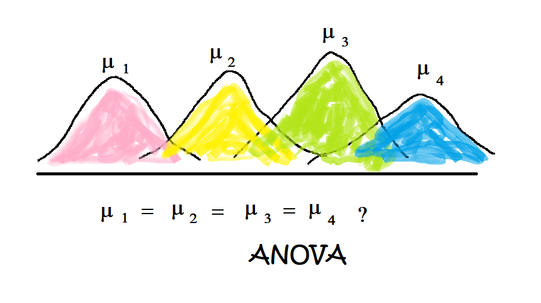

- En terminologia de l’anàlisi de la variància anomenem

> – **factor** a la característica que separa els diferents grups o poblacions

> – **nivell** a cadascun dels grups que conformen el factor

### 1.1.1 Exemple 1. Comparació eficàcia de tres fàrmacs

- Volem comparar l’eficàcia de tres fàrmacs (tractaments)
- La **variable resposta** és l’increment que es produeix, després d’haver rebut el tractament, en una determinada variable bioquímica.

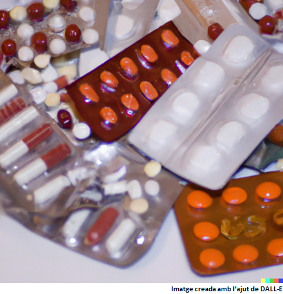

- Teníem una mostra de 24 pacients i els hem repartit de forma **aleatòria** (hem assignat els tractaments a l’atzar) i **balancejada** (mateix número de pacients per tractament) als tres tractaments.

Els resultats han estat els següents

$$\begin{array}{c|c|c|c}
Individu & Tract. 1 & Tract. 2 & Tract. 3 \\ \hline
1 & 4 & 7 & 9 \\
2 & 2 & 6 & 12 \\
3 & 6 & 5 & 6 \\
4 & 6 & 7 & 11 \\
5 & 5 & 6 & 10 \\
6 & 6 & 4 & 11 \\
7 & 2 & 7 & 9 \\
8 & 6 & 5 & 10 \end{array}$$

En aquest cas tenim **un factor** (el tractament) amb **tres nivells**.

**El nostre objectiu és verificar si hi ha relació entre el tractament i la variable resposta**.

### 1.1.2 Terminologia

- **Rèplica**: observacions de la variable resposta fetes sota les mateixes condicions experimentals.
- **Disseny balancejat**: situació experimental on es presenten el mateix nombre de rèpliques en cada grup/tractament .
- **Aleatorització**: un requisit bàsic. Cada unitat observada (cada rèplica) s’ha d’assignar aleatòriament a un tractament.
- **Disseny d’un factor completament aleatoritzat**: disseny on s’analitza la influència d’un únic factor i els individus han estat aleatoritzats.
- **Factor fix**: si els nivells del factor analitzats són tots els rellevants per l’investigador.
- **Factor aleatori**: si els nivells del factor analitzats en l’experiment són una mostra d’un conjunt més gran de possibles nivells (tractaments) del factor.

### 1.1.3 Anàlisi descriptiu de les dades amb R

En aquest primer fragment de codi introduïm les dades, creem el data.frame amb les dues variables i fem un summary del mateix. Fixeu-vos especialment en la declaració com a **factor** de la variable que indentifica els grups de tractament i que queda reflectit al summary en forma de taula de freqüències.

```r
resp<-c(4,2,6,6,5,6,2,6,7,6,5,7,6,4,7,5,9,12,6,11,10,11,9,10)
tract<-factor(rep(1:3,each=8),labels=c('Farmac 1','Farmac 2','Farmac 3'))
farmacs<-data.frame(tract,resp)
summary(farmacs)
```

```
##       tract        resp
##  Farmac 1:8   Min.   : 2.00
##  Farmac 2:8   1st Qu.: 5.00
##  Farmac 3:8   Median : 6.00
##               Mean   : 6.75
##               3rd Qu.: 9.00
##               Max.   :12.00
```

Posteriorment fem una descriptiva separada per grups amb dos possibles presentacions i un boxplot com a eina descriptiva gràfica

```r
tapply(farmacs$resp,farmacs$tract,summary)
```

```
## $`Farmac 1`
##    Min. 1st Qu.  Median    Mean 3rd Qu.    Max.
##   2.000   3.500   5.500   4.625   6.000   6.000
##
## $`Farmac 2`
##    Min. 1st Qu.  Median    Mean 3rd Qu.    Max.
##   4.000   5.000   6.000   5.875   7.000   7.000
##
## $`Farmac 3`
##    Min. 1st Qu.  Median    Mean 3rd Qu.    Max.
##    6.00    9.00   10.00    9.75   11.00   12.00
```

```r
by(farmacs[,2],farmacs$tract,summary)
```

```
## farmacs$tract: Farmac 1
##    Min. 1st Qu.  Median    Mean 3rd Qu.    Max.
##   2.000   3.500   5.500   4.625   6.000   6.000
## ------------------------------------------------------------
## farmacs$tract: Farmac 2
##    Min. 1st Qu.  Median    Mean 3rd Qu.    Max.
##   4.000   5.000   6.000   5.875   7.000   7.000
## ------------------------------------------------------------
## farmacs$tract: Farmac 3
##    Min. 1st Qu.  Median    Mean 3rd Qu.    Max.
##    6.00    9.00   10.00    9.75   11.00   12.00
```

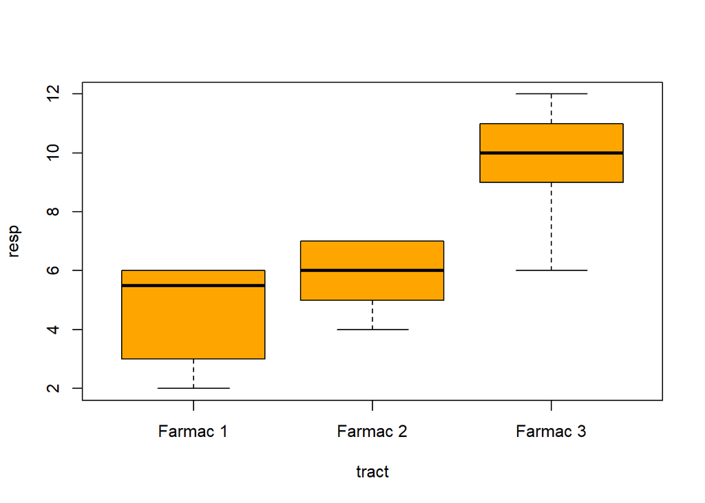

```r
boxplot(resp~tract,data=farmacs,col='orange')
```

### 1.1.4 Comparació de l’eficàcia dels tres fàrmacs

Volem determinar si els tres fàrmacs són igualment eficaços amb un nivell de significació $\alpha$ = 5 %.

Amb les eines que coneixem de primer, acceptant normalitat, i considerant 3 contrasts t de Student per parelles consecutius:

- fàrmac 1 contra fàrmac 2 ($\alpha$=5%)
- fàrmac 1 contra fàrmac 3 ($\alpha$=5%)
- fàrmac 2 contra fàrmac 3 ($\alpha$=5%)

aparentment es resol la qüestió plantejada. Però $\ldots$

aquesta forma directa de plantejar el problema comporta un error metodològic: el nivell de significació de las 3 proves juntes és superior a $\alpha$

si plantegem els dos tests següents

- fàrmac 1 contra fàrmac 2 ($\alpha$=5%)
- fàrmac 1 contra fàrmac 3 ($\alpha$=5%)

els contrasts són independents, la probabilitat de que no ens equivoquem en cap dels dos és el producte de no equivocar-nos en el primer i no equivocar-nos en el segon, per tant l’error de tipus I global (probabilitat d’equivocar-nos en al menys un dels dos) és:

$\alpha_G$ = nivell de significació global = $1-(1-0.05)^2 = 0.0975$

si plantegem els 3 a l’hora, en no ser independents, només podem afirmar que $\alpha_G$ està entre 0.0975 i 0.15.

en general, quan més gran sigui el número de grups, més gran serà $\alpha_G$ **¡acostant-se a 1!**. Cal doncs una tècnica alternativa.

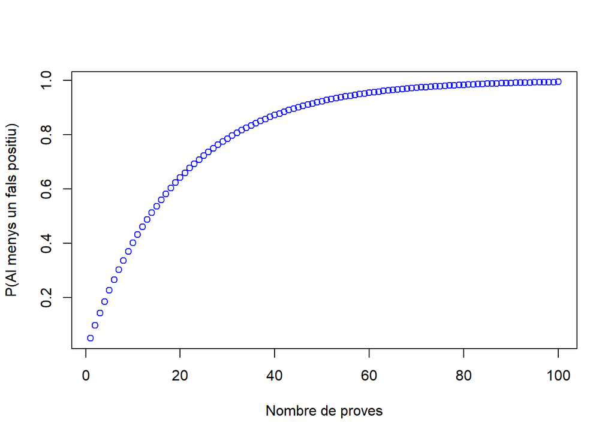

```r
alpha<-0.05
m<-c(1:100)
p<-1-(1-alpha)^m
plot(m,p,xlab='Nombre de proves',ylab='P(Al menys un fals positiu)',col='blue')
```

## 1.2 Model lineal de l’ANOVA un factor fix

Devem les tècniques de l’anàlisi de la variància al estadístic anglès [Ronald A. Fisher](https://en.wikipedia.org/wiki/Ronald_Fisher)

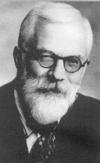

Ronald Fisher

El model lineal assumit per les dades és:

$$Y_{ij} = \mu + \alpha_i +
\epsilon_{ij} \,\,\,\,\,\, i=1,...,a; \,\,\,\, j=1,...,r_i$$

on

- $Y_{ij}$ és el valor de la variable resposta per a l’observació $j$ dintre del nivell $i$ del factor
- $\mu$ és una mitjana general del valor de la variable resposta en el conjunt de tots els individus
- $\alpha_i$ és un paràmetre del model que mesura l’efecte sobre aquesta mitjana del nivell $i$ del factor
- $\epsilon_{ij}$ és l’error aleatori corresponent a una observació concreta $i,j$ i dels quals suposem que són independents i idènticament distribuïts amb $E(\epsilon_{ij}) = 0$ i $Var(\epsilon_{ij})=\sigma^2$.
- També suposem que $\sum_{i=1}^a r_i \alpha_i = 0$. ($\sum_{i=1}^a \alpha_i = 0$ si el disseny és balancejat $(r_1=\ldots=r_a=n)$)

Com veurem serà necessari també assumir una distribució normal sobre els errors

$$\epsilon_{ij} \sim
N(0,\sigma)$$

i per tant cada observació experimental

$$Y_{ij} \sim N(\mu_i,\sigma)$$

on $\mu_i = \mu + \alpha_i$.

### 1.2.1 Contrast d’hipòtesis

L’Anova d’un factor contrasta la hipòtesi que no hi ha efecte dels tractaments. En forma paramètrica, les hipòtesis són:

$$H_0: \alpha_1 = \alpha_2 = \cdots =
\alpha_a = 0$$
$$H_1: \alpha_i
\ne \alpha_{i'} \mbox{ per algun } i \ne i'$$

Si **rebutgem la hipòtesi nul·la**, el test només indica que **no tots els grups són iguals**, però no concretament entre quins d’ells.

Una forma equivalent d’expressar la hipòtesi nul·la és mitjançant les mitjanes poblacionals de cada grup:

$$H_0: \mu_1 = \mu_2 = \cdots = \mu_a$$

### 1.2.2 Estimacions dels paràmetres del model

#### 1.2.2.1 Definicions

– $N=r_1+r_2+\cdots+r_a$

– $Y_{i.} = \sum_{j=1}^{r_i} Y_{ij}$

– $Y_{..} = \sum_{i=1}^{a} Y_{i.}=\sum_{i=1}^{a} \sum_{j=1}^{r_i} Y_{ij}$

– $\overline{Y}_{i.}= \frac{Y_{i.}}{r_i}$

– $\overline{Y}_{..}= \frac{Y_{..}}{N}$

#### 1.2.2.2 Estimadors puntuals dels paràmetres del model

– $\hat{\mu} = \overline{Y}_{..}$

– $\hat{\mu_i} = \overline{Y}_{i.}$

– $\hat{\alpha_i} = \overline{Y}_{i.} - \overline{Y}_{..} \,\,\,\, (\alpha_i = \mu_i - \mu)$

**Nota**: en cas d’un disseny balancejat $(r_1=\ldots=r_a=n)$ aleshores $N = n \cdot a$.

#### 1.2.2.3 Valor predit i residu

– $\hat{Y}_{ij} = \overline{Y_{i.}}$

– $\hat{e}_{ij} = Y_{ij} - \overline{Y_{i.}}$

### 1.2.3 Descomposició de la variabilitat

La idea de Fisher va ser **descomposar la variabilitat total** de les dades en una part deguda a la **variabilitat entre tractaments** i una part deguda a la **variabilitat dintre dels tractaments**.

Posteriorment decidim si els tractaments són significatius **comparant aquestes dues darreres variabilitats**.

Es per això que tot i que estem contrastant mitjanes poblacionals la tècnica s’anomena **anàlisi de la variància**.

$$SS_T = \sum_{i=1}^{a} \sum_{j=1}^{r_i}
(Y_{ij}-\overline{Y}_{..} )^2 =$$
$$\sum_{i=1}^{a} r_i
(\overline{Y}_{i.}-\overline{Y}_{..} )^2 + \sum_{i=1}^{a}
\sum_{j=1}^{r_i} (Y_{ij}-\overline{Y}_{i.} )^2 = SS_A +
SS_E$$

on

- $SS_T$ recull la variabilitat total de les dades,
- $SS_A$ recull la variabilitat entre tractaments i
- $SS_E$ recull la variabilitat dintre dels tractaments

### 1.2.4 Descomposició de la variabilitat en les dades de l’exemple

Presentarem els càlculs fets amb instruccions bàsiques de llenguatge R per entendre millor l’origen dels valors.

```r
SST<-sum((resp-mean(resp))^2)
aux<-tapply(farmacs$resp,farmacs$tract,mean)
SSA<-8*sum((aux-mean(resp))^2)
aux2<-rep(aux,each=8)
SSE<-sum((resp-aux2)^2)
c(SST,SSA,SSE)
```

```
## [1] 168.50 114.25  54.25
```

Com podem arribar a decidir si la variabilitat entre tractaments és prou important com per dir que l’efecte dels tractaments és significatiu?

### 1.2.5 Esperances dels quadrats mitjans

Si anomenem $MS_E = \frac{SS_E}{N-a}$ (quadrats mitjans de l’error) pot demostrar-se que $E(MS_E) = \sigma^2$ sempre.

Per una altra banda si anomenem $MS_A = \frac{SS_A}{a-1}$ (quadrats mitjans entre tractaments) pot demostrar-se que $E(MS_A) = \sigma^2 + \frac{\sum_{i=1}^a r_i \alpha_i^2}{a-1}$.

Per tant i si la hipòtesi nul·la és certa ($H_0: \alpha_1 = \alpha_2 = \cdots = \alpha_a = 0) \Rightarrow E(MS_A)=E(MS_E)=\sigma^2$ i per tant si plantegem

$$F = \frac{MS_A}{MS_E} \approx 1$$

En canvi si $H_0$ és falsa la tendència ha de ser que $F > 1$.

$$F = \frac{MS_A}{MS_E} =
\frac{\frac{SS_A}{a-1}}{\frac{SS_E}{N-a}}$$

- Si $H_0$ és certa , $F$ tendirà a ser propera a 1.
- Si $H_0$ és falsa , $F$ tendirà a ser més gran que 1.

Per tant un criteri raonable per decidir consisteix en rebutjar $H_0$ si $F$ és prou gran

Si $F \ge c_\alpha \Rightarrow$ rebutgem $H_0$, on $c_\alpha$ és triat de forma que $P_{H_0} (F \ge c_\alpha) = \alpha$.

Per trobar $c_\alpha$ pot demostrar-se que sota la hipòtesi de errors normals i homocedàstics

$$\epsilon_{ij} \sim
N(0,\sigma)$$

$\frac{MS_A}{\sigma^2}$ i $\frac{MS_E}{\sigma^2}$ segueixen una distribució $\chi^2$ amb $a-1$ i $N-a$ graus de llibertat respectivament i són independents, i com a conseqüència

$$F = \frac{MS_A}{MS_E} =
\frac{\frac{SS_A}{a-1}}{\frac{SS_E}{N-a}} \sim F(a-1,N-a)$$

on $F(a-1,N-a)$ és una distribució $F$ de Fisher amb $a-1$ graus de llibertat en el numerador i $N-a$ graus de llibertat en el denominador.

### 1.2.6 Taula de l’Anàlisi de la variància (ANOVA)

| Font de variació | Suma de quadrats | Graus de llibertat | Quadrats mitjans | Estadístic F |
| --- | --- | --- | --- | --- |
| Entre tractaments | $SS_A$ | $a-1$ | $MS_A = \frac{SS_A}{a-1}$ | $F = \frac{MS_A}{MS_E}$ |
| Error (dintre nivells) | $SS_E$ | $N-a$ | $MS_E = \frac{SS_E}{N-a}$ |  |
| Total | $SS_T$ | $N-1$ |  |  |

- Criteri de decisió

> – Calcular el valor de l’estadístic $F$ de la taula a partir de les dades.

> – Determinar el valor crític $F_{\alpha} (a-1,N-a)$ per a una distribució $F$ de Fisher amb $a-1$ graus de llibertat en el numerador i $N-a$ graus de llibertat en el denominador d’acord amb $\alpha$.

> – Si $F \ge F_{\alpha} (a-1,N-a)$ rebutjarem $H_0$ o, equivalentment, si el p-valor és prou petit i obtenim el resultat amb un software estadístic.

[figure not shown]

### 1.2.7 Taula de l’Anàlisi de la variància (ANOVA) (exemple)

| Font de variació | Suma de quadrats | Graus de llibertat | Quadrats mitjans | Estadístic F |
| --- | --- | --- | --- | --- |
| Entre tractaments | 114.25 | 2 | 57.125 | $F =$ 22.113 |
| Error (dintre nivells) | 54.25 | 21 | 2.5833 |  |
| Total | 168.50 | 23 |  |  |

Valor crític $F_{0.05} (2,21) = 3.4668$ .

La decisió és **rebutjar la hipòtesi nul·la** i concloure que **no tots els tractaments són equivalents** per a la variable resposta.

### 1.2.8 Resolució amb R

La forma més bàsica de resolució és amb la funció **aov** de R per ajustar els paràmetres del model i posteriorment la funció **anova** per construir la taula.

```r
# anova
farmacs.aov<-aov(resp~tract,farmacs)
anova(farmacs.aov)
```

|  | Df | Sum Sq | Mean Sq | F value | Pr(>F) |
| --- | --- | --- | --- | --- | --- |
| tract | 2 | 114.25 | 57.125000 | 22.1129 | 6.8e-06 |
| Residuals | 21 | 54.25 | 2.583333 | NA | NA |

Amb la función **model.tables** podem obtenir les estimacions dels paràmetres del model.

```r
# taules de coefficients i mitjanes
taula<-model.tables(farmacs.aov,type='mean')
taula
```

```
## Tables of means
## Grand mean
##
## 6.75
##
##  tract
## tract
## Farmac 1 Farmac 2 Farmac 3
##    4.625    5.875    9.750
```

- Estimació dels paràmetres del model

> – $\hat{\mu} =$ 6.75

> – $\hat{\alpha_1}$ = 4.625 - 6.75 = -2.125

> – $\hat{\alpha_2}$ = 5.875 - 6.75= -0.875

> – $\hat{\alpha_3}$ = 9.75 - 6.75= 3

> – $\hat{\sigma^2}$ = 2.5833333 $\Rightarrow \hat{\sigma}$ = 1.6072751

Els coeficients poden obtenir-se directament amb la instrucció

```r
model.tables(farmacs.aov) # per defecte type="effects"
```

```
## Tables of effects
##
##  tract
## tract
## Farmac 1 Farmac 2 Farmac 3
##   -2.125   -0.875    3.000
```

### 1.2.9 Intervals de confiança pels paràmetres del model

A partir del fet que

$$\hat{\mu_i} = \overline{Y}_{i.} \sim
N(\mu_i,\frac{\sigma}{\sqrt{r_i}}) \Rightarrow \frac{
\overline{Y}_{i.}-\mu_i}{\frac{\sigma}{\sqrt{n}}} \sim N(0,1)$$

si substituïm $\sigma^2$ pel seu estimador $MS_E$:

$$\frac{
\overline{Y}_{i.}-\mu_i}{\sqrt{\frac{MS_E}{r_i}}} \sim t_{N-a},$$

tenim com a interval de confiança al $(1-\alpha) \cdot 100 \%$ per $\mu_i$:

$$\overline{Y}_{i.} \pm
t_{(\alpha/2,N-a)} \cdot \sqrt{\frac{MS_E}{r_i}}$$

- En el nostre exemple $N-a = 21$ i amb una confiança del 95 % $t_{(0.025,21)}=2.080$, resultant els següents intervals:

– Per $\mu_1$: 4.625 $\pm$ 2.080 $\sqrt{\frac{2.583}{8}} =$ (3.4431005 , 5.8068995)

– Per $\mu_2$: 5.875 $\pm$ 2.080 $\sqrt{\frac{2.583}{8}} =$ (4.6931005 , 7.0568995)

– Per $\mu_3$: 9.75 $\pm$ 2.080 $\sqrt{\frac{2.583}{8}} =$ (8.5681005 , 10.9318995)

#### 1.2.9.1 Amb R i les dades del exemple

```r
confint(aov(resp~tract-1,farmacs))
```

```
##                  2.5 %    97.5 %
## tractFarmac 1 3.443244  5.806756
## tractFarmac 2 4.693244  7.056756
## tractFarmac 3 8.568244 10.931756
```

### 1.2.10 Mida de l’efecte

La mida de l’efecte és un nom que rep una família d’índexs que mesuren la magnitud del efecte de tractament o de la força de la relació entre dues variables. A diferència de les proves de significació, aquests índexs són independents de la mida de la mostra, això és important perquè amb una mostra prou gran, una prova estadística demostrarà gairebé sempre una diferència significativa, tret que no hi hagi absolutament cap diferència; tot i que les diferències siguin molt petites, tant petites que no tinguin cap significació aplicada. Per tant, informar només del p-valor significatiu per a una anàlisi no és adequat per entendre els resultats completament.

En l’àmbit de l’anàlisi de la variància els índexs més utilitzats per indicar la mida de l’efecte són:

- $Eta^2 (\eta^2)$

$$\eta^2 = \frac{SSA}{SST}$$

Al nostre exemple: $\eta^2=\frac{114.25}{168.5}=0.68$

- $f$ de Cohen

$$f=\sqrt{\frac{\eta^2}{1-\eta^2}}=\sqrt{\frac{SSA}{SSE}}$$
Al nostre exemple: $f=\sqrt{\frac{114.25}{54.25}}=1.45$

#### 1.2.10.1 Obtenció amb R amb el *package* **effectsize**

```r
library(effectsize)
eta_squared(farmacs.aov,ci=0.95)
```

| Parameter | Eta2 | CI | CI_low | CI_high |
| --- | --- | --- | --- | --- |
| tract | 0.6780415 | 0.95 | 0.4492991 | 1 |

```r
cohens_f(farmacs.aov,ci=0.95)
```

| Parameter | Cohens_f | CI | CI_low | CI_high |
| --- | --- | --- | --- | --- |
| tract | 1.451203 | 0.95 | 0.903254 | Inf |

### 1.2.11 Verificació de les premisses del ANOVA

Per tal de poder aplicar la teoria dels models lineals, es requereixen tres requisits:

- **Homoscedasticitat**: igualtat de les variàncies en tots els grups
- **Normalitat** dels residus
- **Independència** de les observacions

El test $F$ del ANOVA pot arribar a ser poc creïble si es fa un estudi amb mides mostrals diferents combinades amb dades no normals de diferent variància.

### 1.2.12 Verificació de la homoscedasticitat

Es potser la premissa a verificar amb més cura.

A través de simulacions pot comprovar-se quina afectació en l’error de tipus I pot provocar una violació de les premisses. Pot arribar a ser molt important, sobretot si es treballa amb dissenys no balancejats.

Un disseny balancejat pot esmorteir en part l’impacte que té sobre el nivell de significació real una desviació moderada de la homoscedasticitat.

Les proves de Bartlett i Levene són algunes de les més populars per verificar la homoscedasticitat.

En elles la hipòtesi nul·la és la homogeneïtat de variàncies.

$$H_0: \sigma_1^2 = \sigma_2^2 = \cdots =
\sigma_a^2$$
$$H_1: \sigma_i^2
\ne \sigma_{i'}^2 \mbox{ per algun } i \ne i'$$

El test de Levene és menys sensible a desviacions de la normalitat.

- [Test de Bartlett (Wikipedia)](https://en.wikipedia.org/wiki/Bartlett%27s_test)
- [Test de Levene (Wikipedia)](https://en.wikipedia.org/wiki/Levene%27s_test)

#### 1.2.12.1 Tests de Bartlett i Levene amb R i dades de l’exemple

```r
bartlett.test(resp~tract,farmacs)
```

```
##
##  Bartlett test of homogeneity of variances
##
## data:  resp by tract
## Bartlett's K-squared = 1.7073, df = 2, p-value = 0.4259
```

```r
library(car)
leveneTest(resp~tract,farmacs)
```

|  | Df | F value | Pr(>F) |
| --- | --- | --- | --- |
| group | 2 | 0.4174312 | 0.6640836 |
|  | 21 | NA | NA |

També es pot fer en forma gràfica analitzant els residus.

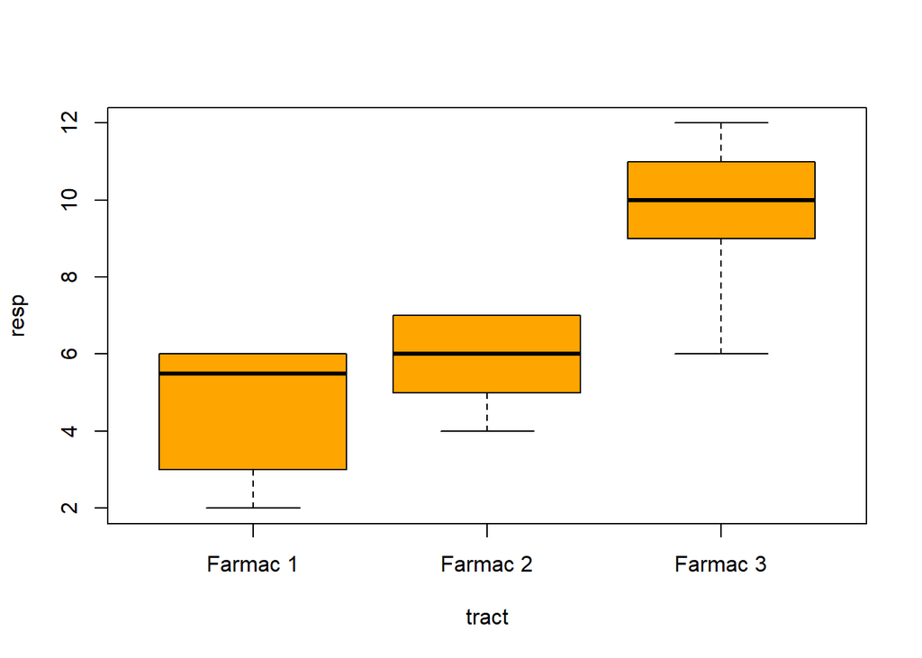

```r
boxplot(resp~tract,data=farmacs,col='orange')
```

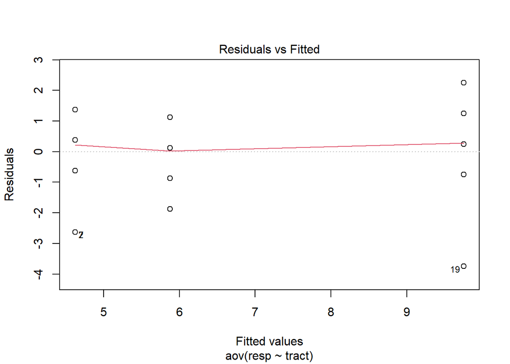

```r
plot(farmacs.aov,which=1)
```

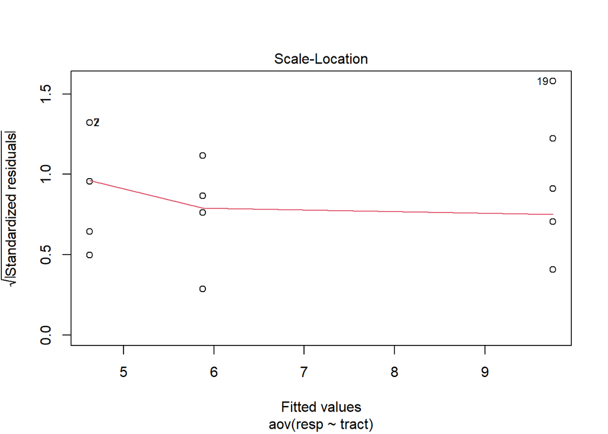

```r
plot(farmacs.aov,which=3)
```

#### 1.2.12.2 Què fer en cas de heterocedasticitat

Si les variàncies són diferents com a possibles solucions tenim la transformació de la variable, si la heterogeneïtat és deguda a una distribució esbiaixada de la variable resposta o alternativament ajustant models lineals generalitzats que permeten ajustar diferents distribucions als errors del model. En posteriors temes estudiarem amb més detall les transformacions de variables.

### 1.2.13 Verificació de la normalitat dels residus

Por fer-se per mitjans gràfics: QQ-plots o histogrames

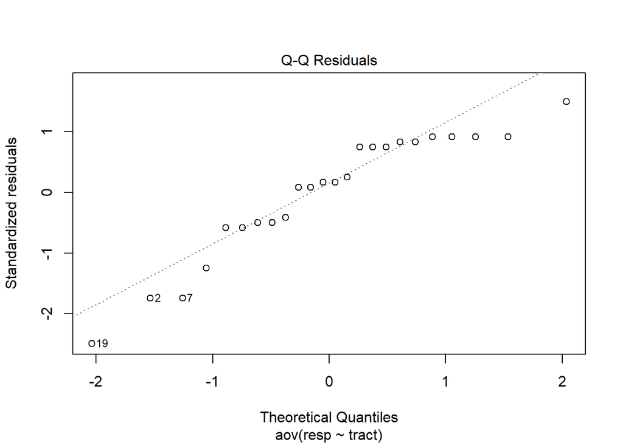

```r
plot(farmacs.aov,which=2)
```

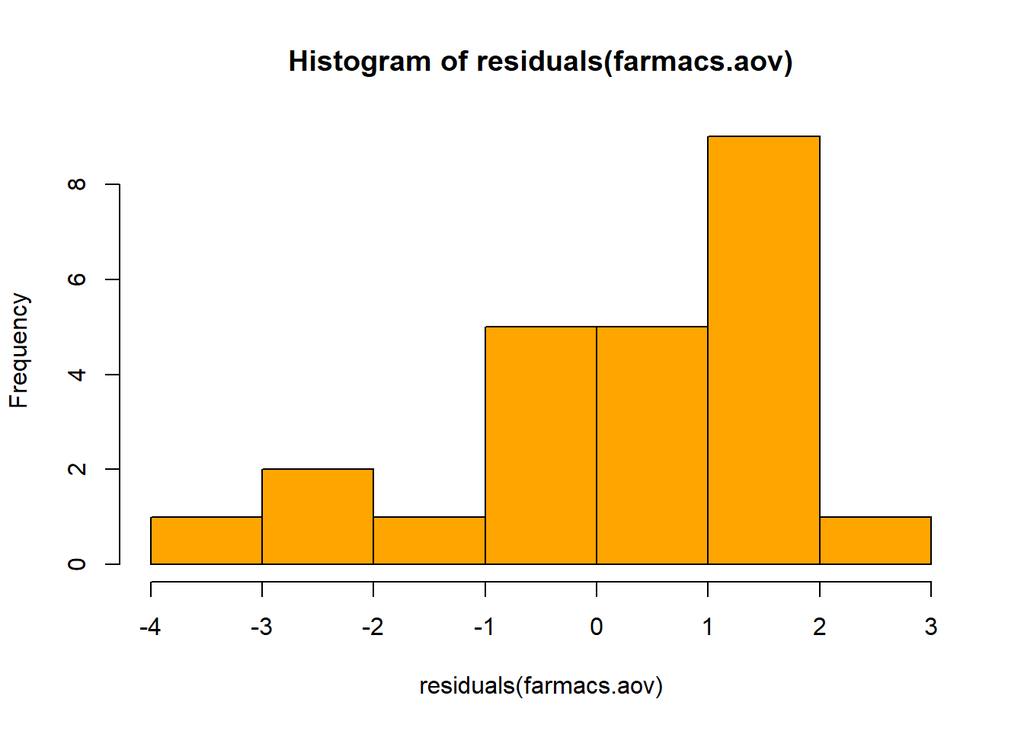

```r
hist(residuals(farmacs.aov),col='orange')
```

o també pot comprovar-se a través de diferents tests de normalitat: Shapiro-Wilks, Kolmogorov-Smirnov-Lilliefors,…

Amb mostres petites és més informatiu utilitzar les tècniques gràfiques.

El test $F$ és robust front a desviacions moderades de la normalitat si els residus tenen una distribució simètrica i sobre tot en el cas de mides mostrals i variàncies similars.

```r
shapiro.test(farmacs.aov$residuals)
```

```
##
##  Shapiro-Wilk normality test
##
## data:  farmacs.aov$residuals
## W = 0.90654, p-value = 0.02968
```

#### 1.2.13.1 Què fer en cas de no normalitat

Existeixen alternatives no paramètriques en cas de una accentuada no normalitat de les dades.

### 1.2.14 Verificació de la independència de les observacions

La millor forma de garantir la independència és amb un model adient de mostratge i amb l’aleatorització prèvia a l’assignació dels tractaments i, si s’escau, en el moment de la lectura de la variable resposta.

### 1.2.15 Comparacions múltiples

- **Un cop que l’ANOVA ha estat significatiu** l’objectiu és decidir quins grups concrets presenten diferències.

– No és raonable fer comparacions dos a dos utilitzant la prova t de Student habitual per les consideracions fetes al principi del tema on veiem que es descontrolava la probabilitat de l’error de tipus I. Hem d’assegurar un nivell de significació global $\le \alpha$.

- Els tests de comparacions múltiples es diferencien entre sí per la forma en que garanteixen el nivell de significació global $\alpha_G$ (possible error de tipus I considerant **totes les proves per parelles** en conjunt).

– la garantia sobre $\alpha_G$ es tradueix de forma diferent segons la tècnica escollida en el nivell de significació individual de cada prova per parelles.

#### 1.2.15.1 Contrastos conservadors i lliberals

- **Test conservador**: per tal de mantenir el nivell de significació global proper (o igual) al nominal, disminueix el valor del nivell de comparació individual.

– Conseqüència: tendeix a acceptar en excés $H_0$ (la igualtat de la parella de mitjanes), és poc potent.

- **Test lliberal**: per tal de mantenir el nivell de comparació individual proper al nominal, relaxa el control sobre el nivell de significació global.

– Conseqüència: tendeix a rebutjar en excés $H_0$.

### 1.2.16 Comparacions múltiples per parelles no planificades (Post hoc)

#### 1.2.16.1 Mètode de Bonferroni

Utilitza la **desigualtat de Bonferroni**

$$P(E_1 \cup E_2 \cup \ldots \cup E_k)
\le P(E_1)+P(E_2)+ \cdots + P(E_k)$$

El nivell de significació global $\le \alpha$ queda assegurat si el nivell de significació de cada prova individual es fixa a $\alpha/k$.

Es un mètode molt general però a costa de gran pèrdua de potència.

#### 1.2.16.2 Diferència mínima significativa de Fisher (FPLSD)

Equival al test t però substituint l’estimació de les variàncies per $MS_E$ obtingut de la taula ANOVA i fa servir com a referència una t de Student de N-a graus de llibertat.

#### 1.2.16.3 Prova HSD de Tukey

Basada en la distribució del **rang studentitzat** per un grup de $a$ mitjanes

$$S_{\overline{Y}} =
\sqrt{\frac{MS_e}{n_0}} \,\,\,\, n_0 = \Big\{ \begin{array}{ll}
n & \mbox{ si } r_1=r_2=...=r_a=n \\
\frac{a}{\sum_{i=1}^a 1/r_i} & \mbox{ si } r_i \ne r_k \end{array}$$

Totes les diferències $|\overline{Y}_i - \overline{Y}_k|$ es comparen amb un únic valor crític $T=q_\alpha (a,N-a) S_{\overline{Y}}$.

#### 1.2.16.4 Prova de Scheffé

Utilitza el valor crític

$$c_\alpha (i,k) = S_{ik}
\sqrt{(a-1)F_\alpha (a-1,N-a)} \,\,\,\, S_{ik}=\sqrt{MS_E (1/r_i+1/r_k)}$$

i rebutja si $|\overline{Y}_i - \overline{Y}_k| \ge c_\alpha (i,k)$

Els intervals de confiança de la forma $\overline{Y}_i - \overline{Y}_k \pm c_\alpha (i,k)$ són intervals de confiança simultanis per les diferències $\mu_i-\mu_k$ amb nivell de confiança com a mínim $1-\alpha$.

### 1.2.17 Classificació dels tests de comparacions múltiples

| Mètode | Característica |
| --- | --- |
| Bonferroni | + Conservador (poca potència) (si es fan moltes comparacions) |
| Scheffé | Conservador |
| Tukey HSD | **Recomanat** |
| Fisher FPLSD | + Liberal (més potència) |

- L’investigador ha de valorar les conseqüències de cometre l’error de tipus I o el de tipus II a la hora de triar la tècnica de comparacions múltiples.

#### 1.2.17.1 Test de Dunnet per comparar grups vs. control

Es un test específic per quan existeix un grup control i l’objectiu és comparar la resta de grups amb el control i no tots entre ells.

Rebutja la hipòtesi nul·la si $|\overline{Y}_i - \overline{Y}_a| \ge d_\alpha (a-1,N-a) \sqrt{MS_E (1/r_i+1/r_a)}$ on assumim que $a$ és el grup control.

### 1.2.18 Comparacions múltiples amb R

La funció **TukeyHSD** inclosa la distribució bàsica de R proporciona un llistat de les comparacions dos a dos per la tècnica de Tukey i el p-valor per a cada comparació.

```r
TukeyHSD(farmacs.aov)
```

```
##   Tukey multiple comparisons of means
##     95% family-wise confidence level
##
## Fit: aov(formula = resp ~ tract, data = farmacs)
##
## $tract
##                    diff        lwr      upr     p adj
## Farmac 2-Farmac 1 1.250 -0.7756249 3.275625 0.2865063
## Farmac 3-Farmac 1 5.125  3.0993751 7.150625 0.0000073
## Farmac 3-Farmac 2 3.875  1.8493751 5.900625 0.0002592
```

Si hi han molts grups el nombre de comparacions creix ràpidament i és més eficaç utilitzar alguna funció que ens agrupi les poblacions segons hi hagi o no diferències entre elles. El *package* **agricolae** proporciona una família de funcions per fer comparacions múltiples per diverses tècniques.

```r
library(agricolae)
HSD.test(farmacs.aov,'tract',console=T)
```

```
##
## Study: farmacs.aov ~ "tract"
##
## HSD Test for resp
##
## Mean Square Error:  2.583333
##
## tract,  means
##
##           resp      std r        se Min Max Q25  Q50 Q75
## Farmac 1 4.625 1.767767 8 0.5682576   2   6 3.5  5.5   6
## Farmac 2 5.875 1.125992 8 0.5682576   4   7 5.0  6.0   7
## Farmac 3 9.750 1.832251 8 0.5682576   6  12 9.0 10.0  11
##
## Alpha: 0.05 ; DF Error: 21
## Critical Value of Studentized Range: 3.564625
##
## Minimun Significant Difference: 2.025625
##
## Treatments with the same letter are not significantly different.
##
##           resp groups
## Farmac 3 9.750      a
## Farmac 2 5.875      b
## Farmac 1 4.625      b
```

```r
LSD.test(farmacs.aov,'tract',console=T)
```

```
##
## Study: farmacs.aov ~ "tract"
##
## LSD t Test for resp
##
## Mean Square Error:  2.583333
##
## tract,  means and individual ( 95 %) CI
##
##           resp      std r        se      LCL       UCL Min Max Q25  Q50 Q75
## Farmac 1 4.625 1.767767 8 0.5682576 3.443244  5.806756   2   6 3.5  5.5   6
## Farmac 2 5.875 1.125992 8 0.5682576 4.693244  7.056756   4   7 5.0  6.0   7
## Farmac 3 9.750 1.832251 8 0.5682576 8.568244 10.931756   6  12 9.0 10.0  11
##
## Alpha: 0.05 ; DF Error: 21
## Critical Value of t: 2.079614
##
## least Significant Difference: 1.671256
##
## Treatments with the same letter are not significantly different.
##
##           resp groups
## Farmac 3 9.750      a
## Farmac 2 5.875      b
## Farmac 1 4.625      b
```

```r
scheffe.test(farmacs.aov,'tract',console=T)
```

```
##
## Study: farmacs.aov ~ "tract"
##
## Scheffe Test for resp
##
## Mean Square Error  : 2.583333
##
## tract,  means
##
##           resp      std r        se Min Max Q25  Q50 Q75
## Farmac 1 4.625 1.767767 8 0.5682576   2   6 3.5  5.5   6
## Farmac 2 5.875 1.125992 8 0.5682576   4   7 5.0  6.0   7
## Farmac 3 9.750 1.832251 8 0.5682576   6  12 9.0 10.0  11
##
## Alpha: 0.05 ; DF Error: 21
## Critical Value of F: 3.4668
##
## Minimum Significant Difference: 2.116117
##
## Means with the same letter are not significantly different.
##
##           resp groups
## Farmac 3 9.750      a
## Farmac 2 5.875      b
## Farmac 1 4.625      b
```

```r
LSD.test(farmacs.aov,'tract',console=T,p.adj = 'bonferroni')
```

```
##
## Study: farmacs.aov ~ "tract"
##
## LSD t Test for resp
## P value adjustment method: bonferroni
##
## Mean Square Error:  2.583333
##
## tract,  means and individual ( 95 %) CI
##
##           resp      std r        se      LCL       UCL Min Max Q25  Q50 Q75
## Farmac 1 4.625 1.767767 8 0.5682576 3.443244  5.806756   2   6 3.5  5.5   6
## Farmac 2 5.875 1.125992 8 0.5682576 4.693244  7.056756   4   7 5.0  6.0   7
## Farmac 3 9.750 1.832251 8 0.5682576 8.568244 10.931756   6  12 9.0 10.0  11
##
## Alpha: 0.05 ; DF Error: 21
## Critical Value of t: 2.60135
##
## Minimum Significant Difference: 2.090543
##
## Treatments with the same letter are not significantly different.
##
##           resp groups
## Farmac 3 9.750      a
## Farmac 2 5.875      b
## Farmac 1 4.625      b
```

## 1.3 ANOVA d’un factor aleatori: Comparació nivell de sodi a les cerveses de Catalunya

- Es desitja comparar si el contingut de sodi de les cerveses comercialitzades a Catalunya es homogeni independentment de la marca.

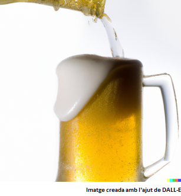

- Es **seleccionen a l’atzar quatre marques de cervesa** (genèricament serien quatre tractaments) i es mesura el nivell de sodi en quatre ampolles triades a l’atzar de cada marca.
- El fet important és que el nombre de nivells del factor estudiats (les quatre marques de cervesa) és **inferior al nombre de possibles tractaments** (totes les marques de cervesa) i que la conclusió de l’anàlisi voldríem que fos vàlida pel conjunt de totes les marques.
- En aquest cas diríem que el factor marca de cervesa és un **factor aleatori**.

Els resultats en *mg* per ampolla han estat els següents

$$\begin{array}{c|c|c|c|c}
Ampolla & Marca 1 & Marca 2 & Marca 3 & Marca 4 \\
\hline
1 & 18 & 11 & 16 & 15\\
2 & 17 & 10 & 15 & 16 \\
3 & 19 & 13 & 17 & 19 \\
4 & 16 & 12 & 15 & 18 \end{array}$$

### 1.3.1 Model lineal de l’ANOVA d’un factor aleatori

El model lineal assumit per les dades es:

$$Y_{ij} = \mu + A_i +
\epsilon_{ij} \,\,\,\,\,\, i=1,...,a; \,\,\,\, j=1,...,r_i$$

on

- $Y_{ij}$ és l’observació $j$ pel nivell $i$ del factor
- $\mu$ és una mitjana general
- $A_i$ és una variable aleatòria, no un paràmetre constant. Assumim que $E(A_i)=0$ i que la $Var(A_i)=\sigma^2_A$.
- $\epsilon_{ij}$ és l’error aleatori corresponent a l’observació $i,j$ i dels quals suposem que són independents i idènticament distribuïts amb $E(\epsilon_{ij}) = 0$ i $Var(\epsilon_{ij})=\sigma^2$.
- També assumim que $A_i$ i $\epsilon_{ij}$ són totes independents, i per tant $Var(Y_{ij})=\sigma^2_A+\sigma^2$ i $E(Y_{ij})=\mu$.

$$A_i \sim N(0,\sigma_A^2) \,\,\,\, ,
\,\,\, \epsilon_{ij} \sim N(0,\sigma^2)$$

i per tant cada observació experimental

$$Y_{ij} \sim
N(\mu,\sqrt{\sigma^2_A+\sigma^2})$$

### 1.3.2 Contrast d’hipòtesis

L’Anova d’un factor aleatori contrasta la hipòtesi que no hi ha variabilitat de la variable resposta deguda als grups. En forma paramètrica, les hipòtesis són:

$$H_0: \sigma_A^2 = 0$$
$$H_1: \sigma_A^2 > 0$$

La descomposició de la suma de quadrats continua essent vàlida $SS_T = SS_A + SS_E$ però els quadrats mitjans tenen un altre sentit

$$E(MS_E) = \sigma^2 \,\,\,\, E(MS_A) =
\sigma^2 + n \sigma^2_A$$

Nota: en el cas balancejat $r_1=r_2=...=r_a=n$.

Continua essent vàlida la conclusió sobre l’estadístic de test. Si la hipòtesi nul·la és certa

$$F = \frac{MS_A}{MS_E} \approx 1$$

En canvi si $H_0$ és falsa la tendència ha de ser que $F > 1$. I novament sota la hipòtesi de normalitat

$$F = \frac{MS_A}{MS_E} =
\frac{\frac{SS_A}{a-1}}{\frac{SS_E}{N-a}} \sim F(a-1,N-a)$$

on $F(a-1,N-a)$ és una distribució $F$ de Fisher amb $a-1$ graus de llibertat en el numerador i $N-a$ graus de llibertat en el denominador.

Es a dir la **taula ANOVA**, el p-valor i la conclusió sobre $H_0$ **són idèntics al cas d’un factor fixe**. La interpretació dels resultats, però, és diferent.

Hem de destacar que la coincidència de les taules ANOVA entre el model de factor fix i el de factor aleatori es produeix en el cas d’un factor, com veurem més endavant **en general això no és cert**.

| Font de variació | Suma de quadrats | Graus de llibertat | Quadrats mitjans | Estadístic F |
| --- | --- | --- | --- | --- |
| Entre tractaments | $SS_A$ | $a-1$ | $MS_A = \frac{SS_A}{a-1}$ | $F = \frac{MS_A}{MS_E}$ |
| Error (dintre nivells) | $SS_E$ | $N-a$ | $MS_E = \frac{SS_E}{N-a}$ |  |
| Total | $SS_T$ | $N-1$ |  |  |

### 1.3.3 Resolució de l’Exemple 2 amb R

La resolució fins arribar a la taula ANOVA és idèntica al cas d’un factor fix.

```r
resp<-c(18,11,16,15,17,10,15,16,19,13,17,19,16,12,15,18)
marca<-factor(rep(1:4,times=4),labels=c('Marca 1','Marca 2','Marca 3','Marca 4'))
beers<-data.frame(marca,resp)
# anova
beers.aov<-aov(resp~marca,beers)
anova(beers.aov)
```

|  | Df | Sum Sq | Mean Sq | F value | Pr(>F) |
| --- | --- | --- | --- | --- | --- |
| marca | 3 | 89.1875 | 29.729167 | 15.68132 | 0.0001878 |
| Residuals | 12 | 22.7500 | 1.895833 | NA | NA |

### 1.3.4 Correlació intraclàssica

En un model d’efectes aleatoris les observacions dintre del mateix nivell del factor aleatori poden ser dependents (el contingut de sodi de les ampolles d’una mateixa marca)

$$Cov(Y_{ij},Y_{ik}) =
Cov(\mu+A_i+\epsilon_{ij},\mu+A_i+\epsilon_{ik})= \\
Cov(A_i,A_i)+cov(A_i,\epsilon_{ik})+Cov(\epsilon_{ij},A_i)+Cov(\epsilon_{ij},\epsilon_{ik})=\sigma_A^2+0+0+0
= \sigma_A^2$$

$$\rho(Y_{ij},Y_{ik})=\frac{Cov(Y_{ij},Y_{ik})}{\sqrt{Var(Y_{ij})Var(Y_{ik})}}=\frac{\sigma_A^2}{\sigma_A^2+\sigma^2}$$

S’interpreta com el percentatge de la variabilitat total degut a la variabilitat introduïda pel factor. Fixem-nos que si la hipòtesi nul·la és certa la correlació intraclàssica val 0.

### 1.3.5 Estimació dels paràmetres del model

$$\hat{\sigma^2} = MS_E$$

$$\hat{\sigma^2_A} =
\frac{MS_A-MS_E}{n_0}$$
on
$$n_0 =
\Bigg\{ \begin{array}{l}
n \mbox{ en el cas balancejat} \\
\frac{1}{a-1} \Big[ \sum_{i=1}^a r_i - \frac{\sum_{i=1}^a
r_i^2}{\sum_{i=1}^a r_i} \Big] \,\, \mbox{ en el cas no
balancejat} \end{array}$$

Aquesta estimació correspon al mètode dels moments aïllant els paràmetres a partir de les esperances

$$E(MS_E) = \sigma^2 \,\,\,\, E(MS_A) =
\sigma^2 + n \sigma^2_A.$$

Pot donar lloc a valors absurds (negatius) per $\hat{\sigma^2_A}$. En aquest cas els substituiríem per zeros.

A la bibliografia poden trobar-se fórmules per intervals de confiança de la correlació intraclàssica.

### 1.3.6 Estimació de paràmetres a l’exemple 2

|  | Df | Sum Sq | Mean Sq | F value | Pr(>F) |
| --- | --- | --- | --- | --- | --- |
| marca | 3 | 89.1875 | 29.729167 | 15.68132 | 0.0001878 |
| Residuals | 12 | 22.7500 | 1.895833 | NA | NA |

- $\hat{\mu} =$ 15.4375
- $\hat{\sigma^2}$ = 1.8958333 $\Rightarrow \hat{\sigma}$ = 1.3768926
- $\hat{\sigma^2_A}$ = (29.7291667 - 1.8958333 )/4 = 6.9583333 $\Rightarrow \hat{\sigma_A}$ = 2.6378653
- La correlació intraclàssica és $r(Y_{ij},Y_{ik}) =$ (6.9583333)/(6.9583333+1.8958333) = 0.7858824

### 1.3.7 Resolució alternativa de l’exemple 2 amb els packages nlme i lme4(opcional)

Aquests packages estan especialitzats en el treball amb factors aleatoris i permeten utilizar tècniques d’estimació millors que el mètode dels moments, per exemple la **màxima versemblança** (MLE) o la **màxima versemblança restringida** (REML). Aquesta darrera produeix millors estimacions dels components de la variància.

Presentem un parell d’exemples de resolució de l’exemple 2 amb les funcions **lme** i **lmer** dels packages **nlme** i **lme4** respectivament.

```r
## Resolució alternativa amb lme
library(nlme)
res.lme<-lme(resp~1,data=beers,random=~1|marca)
summary(res.lme)
```

```
## Linear mixed-effects model fit by REML
##   Data: beers
##        AIC      BIC    logLik
##   69.19303 71.31718 -31.59652
##
## Random effects:
##  Formula: ~1 | marca
##         (Intercept) Residual
## StdDev:    2.637865 1.376893
##
## Fixed effects:  resp ~ 1
##               Value Std.Error DF  t-value p-value
## (Intercept) 15.4375  1.363112 12 11.32519       0
##
## Standardized Within-Group Residuals:
##         Min          Q1         Med          Q3         Max
## -1.38017961 -0.57260166 -0.04341988  0.82574114  1.52491254
##
## Number of Observations: 16
## Number of Groups: 4
```

```r
intervals(res.lme)
```

```
## Approximate 95% confidence intervals
##
##  Fixed effects:
##                lower    est.    upper
## (Intercept) 12.46754 15.4375 18.40746
##
##  Random Effects:
##   Level: marca
##                    lower     est.    upper
## sd((Intercept)) 1.121722 2.637865 6.203258
##
##  Within-group standard error:
##     lower      est.     upper
## 0.9228576 1.3768926 2.0543076
```

```r
library(lme4)
res.lmer<-lmer(resp~1+(1|marca))
summary(res.lmer)
```

```
## Linear mixed model fit by REML ['lmerMod']
## Formula: resp ~ 1 + (1 | marca)
##
## REML criterion at convergence: 63.2
##
## Scaled residuals:
##      Min       1Q   Median       3Q      Max
## -1.38018 -0.57260 -0.04342  0.82574  1.52491
##
## Random effects:
##  Groups   Name        Variance Std.Dev.
##  marca    (Intercept) 6.958    2.638
##  Residual             1.896    1.377
## Number of obs: 16, groups:  marca, 4
##
## Fixed effects:
##             Estimate Std. Error t value
## (Intercept)   15.437      1.363   11.32
```

```r
confint(res.lmer)
```

```
##                  2.5 %    97.5 %
## .sig01       1.1293759  5.748927
## .sigma       0.9672533  2.184005
## (Intercept) 12.4393299 18.435668
```

Per obtenir p-valors amb els resultats de la funció **lmer** utilitzarem el *package* **lmerTest**.

```r
library(lmerTest)
ranova(res.lmer)
```

|  | npar | logLik | AIC | LRT | Df | Pr(>Chisq) |
| --- | --- | --- | --- | --- | --- | --- |
|  | 3 | -31.59652 | 69.19303 | NA | NA | NA |
| (1 \| marca) | 2 | -37.74455 | 79.48910 | 12.29607 | 1 | 0.0004539 |

## 1.4 Calcul de potència i mida mostral

Per tenir en compte la potència del contrast en un ANOVA podem plantejar-nos dues estratègies:

- Calcular la potència a partir de la mida mostral utilitzada
- Calcula la mida mostral necessària per assolir una determinada potència

Utilitzarem el *package* de R **pwr** que inclou funcions per fer el càlcul en diferents situacions. Les funcions tenen com a arguments:

- El número de tractaments: k
- El número de rèpliques per tractament: n
- La mida de l’efecte: f de Cohen
- El nivell de significació: sig.level
- La potència: power

Una crida a les funcions amb tots els arguments excepte un ens dona una sortida on està calculat l’argument faltant.

### 1.4.1 Determinació de la potència

Farem servir la función **pwr.anova.test**.

#### 1.4.1.1 Càlcul sobre les dades del exemple 1

Recordem que vam calcular la mida de l’efecte

```r
library(effectsize)
cohens_f(farmacs.aov,ci=0.95)
```

| Parameter | Cohens_f | CI | CI_low | CI_high |
| --- | --- | --- | --- | --- |
| tract | 1.451203 | 0.95 | 0.903254 | Inf |

Per tant en el nostre cas

```r
f<-1.45
```

```r
library(pwr)
pwr.anova.test(k=3, f=f, sig.level=0.05, n=8)
```

```
##
##      Balanced one-way analysis of variance power calculation
##
##               k = 3
##               n = 8
##               f = 1.45
##       sig.level = 0.05
##           power = 0.9999891
##
## NOTE: n is number in each group
```

### 1.4.2 Càlcul de la mida mostral per assolir una potència determinada

Suposem que volem detectar efectes que excedeixin $\Delta$ unitats de la mitjana global amb un nivell de significació $\alpha$ i una potència $1-\beta$.

Es pot demostrar que

$$f^2 = \frac{\sum_{i=1}^a \alpha_i^2}{a
\cdot \sigma^2}$$

El cas més desfavorable (menor mida del efecte) és $\alpha_1 = \Delta \,\, , \,\, \alpha_2 = -\Delta$ i $\alpha_i = 0 \,\, i=3,...,a$.

Per tant

$$f^2 = \frac{2 \cdot \Delta^2}{a \cdot
\sigma^2}$$

Suposem que en el nostre exemple volem detectar efectes que excedeixin $\Delta=1.5$ unitats la mitjana global, amb un nivell de significació del 5 % i una potència del 80 %. Sota aquestes condicions

$\hat{f} = \sqrt{\frac{2 \cdot 1.5^2}{3 \cdot MS_E}} =$ 0.7620499.

A títol indicatiu, Cohen suggereix valors de f de 0.1, 0.25 i 0.4 que representen efectes petits, mitjans i grans respectivament.

Finalment amb el *package* **pwr**

```r
f<-sqrt((2*1.5^2)/(3*2.583))
pwr.anova.test(k=3, f=f, sig.level=0.05, power=0.8)
```

```
##
##      Balanced one-way analysis of variance power calculation
##
##               k = 3
##               n = 6.638329
##               f = 0.7620499
##       sig.level = 0.05
##           power = 0.8
##
## NOTE: n is number in each group
```

```r
pwr.anova.test(k=3, f=f, sig.level=0.05, power=0.9)
```

```
##
##      Balanced one-way analysis of variance power calculation
##
##               k = 3
##               n = 8.355842
##               f = 0.7620499
##       sig.level = 0.05
##           power = 0.9
##
## NOTE: n is number in each group
```

## 1.5 ANOVA en cas de heteroscedasticitat (Welch generalitzat)

- B. L. Welch va publicar un test alternatiu al test anova pel cas de variàncies no necessariament iguals.
- Els detalls poden consultar-se a:

> B. L. Welch (1951). On the comparison of several mean values: an alternative approach. Biometrika, 38, 330–336. doi:10.2307/2332579.
- Es pot obtenir amb la funció **oneway.test** de R

```r
oneway.test(resp~tract,farmacs)
```

```
##
##  One-way analysis of means (not assuming equal variances)
##
## data:  resp and tract
## F = 17.396, num df = 2.000, denom df = 13.229, p-value = 0.0001979
```

Si ho executem amb l’opció *var.equal=T* el resultat és el mateix que l’anova habitual

```r
oneway.test(resp~tract,farmacs,var.equal=T)
```

```
##
##  One-way analysis of means
##
## data:  resp and tract
## F = 22.113, num df = 2, denom df = 21, p-value = 6.79e-06
```

```r
anova(aov(resp~tract,farmacs))
```

|  | Df | Sum Sq | Mean Sq | F value | Pr(>F) |
| --- | --- | --- | --- | --- | --- |
| tract | 2 | 114.25 | 57.125000 | 22.1129 | 6.8e-06 |
| Residuals | 21 | 54.25 | 2.583333 | NA | NA |

### 1.5.1 Comparacions múltiples

Quan fem un ANOVA amb variàncies desiguals (heterocedasticitat), com el Welch ANOVA (oneway.test en R), no és correcte aplicar directament les proves post-hoc tradicionals (com Tukey HSD), ja que aquestes assumeixen homogeneïtat de variàncies.

Tenim varies alternatives:

- Test de Games-Howell: És una extensió del Tukey HSD per al cas heterocedàstic. No assumeix igualtat de variàncies ni igualtat de grandàries mostral. Manté un bon control del risc d’error tipus I.
- Test T3 de Dunnett: També es recomana quan les variàncies del grup són desiguals i les mides de les mostres difereixen. Es basa en la distribució de rang studentitzat i proporciona un control conservador sobre l’error de tipus I sense assumir homoscedasticitat.
- Efectuar t-tests amb correcció de Welch i ajustar els p-valors per Bonferroni, BH (menys conservador), Holm,…

```r
pairwise.t.test(farmacs$resp, farmacs$tract, p.adjust.method = "bonferroni", pool.sd = FALSE)
```

```
##
##  Pairwise comparisons using t tests with non-pooled SD
##
## data:  farmacs$resp and farmacs$tract
##
##          Farmac 1 Farmac 2
## Farmac 2 0.35308  -
## Farmac 3 0.00017  0.00087
##
## P value adjustment method: bonferroni
```

```r
pairwise.t.test(farmacs$resp, farmacs$tract, p.adjust.method = "BH", pool.sd = FALSE)
```

```
##
##  Pairwise comparisons using t tests with non-pooled SD
##
## data:  farmacs$resp and farmacs$tract
##
##          Farmac 1 Farmac 2
## Farmac 2 0.11769  -
## Farmac 3 0.00017  0.00044
##
## P value adjustment method: BH
```

## 1.6 ANOVA no paramétric. Test de Kruskal-Wallis

- Objectiu del test: comprovar si existeixen diferències significatives entre k grups experimentals.
- Kruskal-Wallis és un test no paramètric que no assumeix normalitat de les dades.
- La hipòtesis nul·la postula que la variable mesurada en els diferents grups presenta la mateixa distribució.
- Assumeix que les formes de les distribucions són les mateixes en els diferents grups, per tant, Kruskal-Wallis és sensible a situacions amb dades heterocedàstiques.
- Generalitza la prova U de Mann-Whitney per a 3 o més grups.

### 1.6.1 Kruskal-Wallis. Procediment

- Procediment
1. ordenar les dades de tota la mostra de més petit a més gran.
2. assignar al més petit el rang=1, al segon rang= 2 etc. El rang de la observació i,j el designem amb el símbol $g_{ij}$
- l’estadístic és el següent:

$$K = \frac{12}{N (N+1)}\sum_{i=1}^a r_i
(\overline{g}_{i.}-\overline{g})^2$$

- en cas de rangs repetits, hi ha descrita una correcció de l’estadístic
- K segueix una distribució Chi-quadrat amb a-1 graus de llibertat, sempre que tot $r_i \ge 5$

### 1.6.2 Exemple 3.

L’exercici físic alleuja la depressió? Seleccionem un conjunt de persones amb un grau equivalent de depressió. A continuació, assignem cada persona aleatòriament a un dels tres grups: sense exercici; 20 minuts de cursa al dia; o 60 minuts de cursa al dia. Després d’un mes, demanem a cada participant que valori el nivell de depressió que sent ara, en l’escala Likert que va des d’1 (“totalment miserable”) fins a 100 (totalment feliç”).

- Dades originals

| Indiv. | Sense exercici | 20 minuts | 60 minuts |
| --- | --- | --- | --- |
| 1 | 23 | 22 | 59 |
| 2 | 26 | 27 | 66 |
| 3 | 51 | 39 | 38 |
| 4 | 49 | 29 | 49 |
| 5 | 58 | 46 | 56 |
| 6 | 37 | 48 | 60 |
| 7 | 29 | 49 | 56 |
| 8 | 44 | 65 | 62 |

- Rangs

| Indiv. | Sense exercici | 20 minuts | 60 minuts |
| --- | --- | --- | --- |
| 1 | 2 | 1 | 20 |
| 2 | 3 | 4 | 24 |
| 3 | 16 | 9 | 8 |
| 4 | 14 | 5.5 | 14 |
| 5 | 19 | 11 | 17.5 |
| 6 | 7 | 12 | 21 |
| 7 | 5.5 | 14 | 17.5 |
| 8 | 10 | 23 | 22 |
| — | — | — | — |
| Mitjana | 9.56 | 9.94 | 18 |
| Mitjana total | 12.5 |  |  |

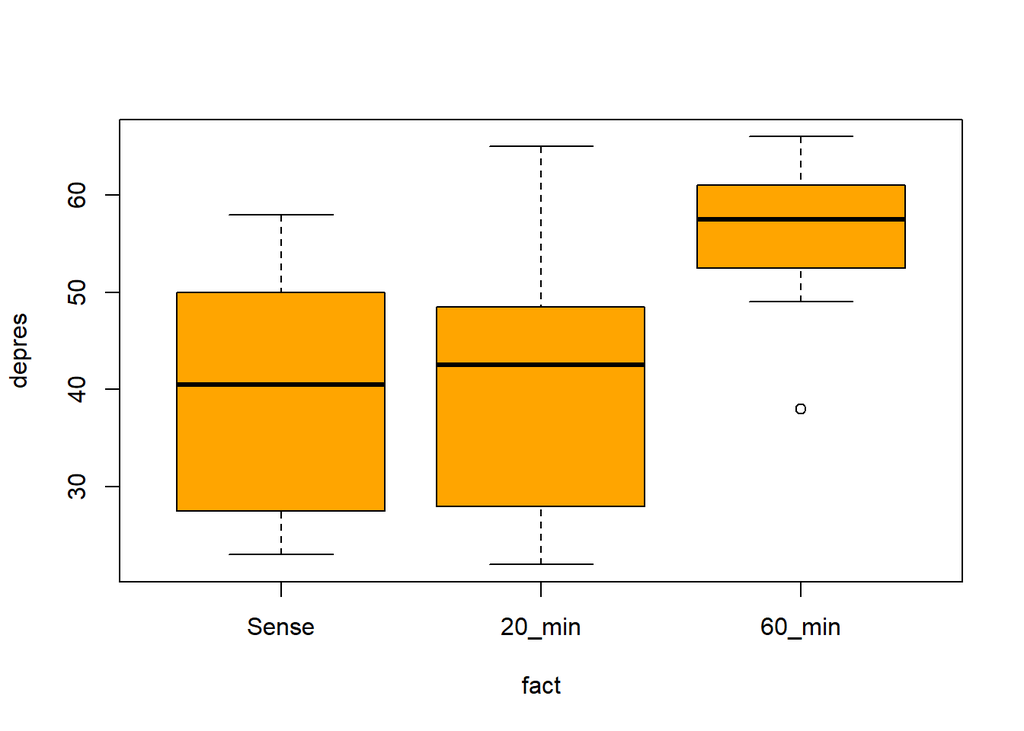

```r
depres<-c(23,26,51,49,58,37,29,44,22,27,39,29,46,48,49,65,59,66,38,49,56,60,56,62)
fact<-factor(c(rep(1,8),rep(2,8),rep(3,8)),labels=c('Sense','20_min','60_min'))
dades<-data.frame(fact,depres)
boxplot(depres~fact,dades,col='orange')
```

El càlcul resumit de l’estadístic és

$$K = \frac{12}{24 \cdot 25}
(8(9.56-12.5)^2+8(9.94-12.5)^2+8(18-12.5)^2)= 7.271552$$

```r
kruskal.test(depres~fact,dades)
```

```
##
##  Kruskal-Wallis rank sum test
##
## data:  depres by fact
## Kruskal-Wallis chi-squared = 7.2903, df = 2, p-value = 0.02612
```

### 1.6.3 Kruskal-Wallis com un ANOVA amb els rangs

Si apliquem el test ANOVA ordinari als rangs com a variable resposta en lloc de la variable original obtindríem

$$F =
\frac{\frac{K}{a-1}}{\frac{N-1-K}{N-a}}$$

Per tant aplicar Kruskal-Wallis és equivalent a aplicar un ANOVA ordinari als rangs de les observacions.

```r
## Kruskal-Wallis com un ANOVA amb els rangs
dades$rang<-rank(dades$depres)
anova(aov(rang~fact,dades))
```

|  | Df | Sum Sq | Mean Sq | F value | Pr(>F) |
| --- | --- | --- | --- | --- | --- |
| fact | 2 | 363.5625 | 181.78125 | 4.872637 | 0.0182654 |
| Residuals | 21 | 783.4375 | 37.30655 | NA | NA |

```r
## F=(K/(a-1))/((N-1-K)/(N-a))  on K és l'estadístic de Kruskal-Wallis
K<-unname(kruskal.test(depres~fact,dades)$statistic)
a<-nlevels(dades$fact)
N<-length(dades$fact)
F<-(K/(a-1))/((N-1-K)/(N-a))
F
```

```
## [1] 4.872637
```

### 1.6.4 Comparacions múltiples per Kruskal-Wallis

```r
library(agricolae)
kruskal(dades$depres,dades$fact,p.adj="bonferroni",console=T)
```

```
##
## Study: dades$depres ~ dades$fact
## Kruskal-Wallis test's
## Ties or no Ties
##
## Critical Value: 7.290268
## Degrees of freedom: 2
## Pvalue Chisq  : 0.02611791
##
## dades$fact,  means of the ranks
##
##        dades.depres r
## 20_min       9.9375 8
## 60_min      18.0000 8
## Sense        9.5625 8
##
## Post Hoc Analysis
##
## P value adjustment method: bonferroni
## t-Student: 2.60135
## Alpha    : 0.05
## Minimum Significant Difference: 7.944404
##
## Treatments with the same letter are not significantly different.
##
##        dades$depres groups
## 60_min      18.0000      a
## 20_min       9.9375      b
## Sense        9.5625      b
```

Una alternativa més lliberal és fer l’ajust dels p-valors per “fdr” en lloc de bonferroni.

Podeu ampliar en el següent enllaç els conceptes de [Comparacions múltiples (*Multiple Testing*)](https://en.wikipedia.org/wiki/Multiple_comparisons_problem)